# Oficina AED

Walter Humberto Subiza Pina

21 de fevereiro de 2017

## Introdução ao Análise Exploratório de Dados

#### 3- Preparando os dados com **tidyverse::dplyr**

Em esse exercício vamos analisar algumas ferramentas do pacote **“dplyr”** também incluído na coleção *tidyverse*.

Hadley Wickham, o autor de dplyr, o chama de **“A Grammar of Data Manipulation”** e é um pacote que ajuda na manipulação, limpeza e preparação de dados para o análise.

O pacote contém diversas funções que permitem aplicar filtros, selecionar ou ordenar colunas, adicionar, deletar ou agregar dados. As funções são simples de chamar e lembrar o que facilita muito o seu uso.

A segunte tabela resume as funções principais.

| função | descrição | exemplo |
| --- | --- | --- |
| filter() | filtra ou seleciona linhas | filter(dados, col3 > 50) |
| select() | Seleciona colunas (variáveis) | select(dados, col3, col5, -col7) |
| mutate() | Cria novas variáveis | mutate(dados, novacol= col1/col4) |
| arrange() | Ordena os dados (desc) | arrange(dados, col2, col3) |
| group_by() | Agrupa os dados acorde critério | group_by(dados, col1, col2) |
| summarise() | Resume ou agrega os dados | Diversas estatísticas |
| join() | Junta ou adiciona dataframes | join(dados1,dados2) |
| distinct() | Elimina observações duplicadas analisando todas as variáveis | distinct(dados) veja? |
| rename() | Muda o nome de uma variável | rename(dados, Coluna01=col1) |
| sample_n() | Seleciona aleatoriamente linhas do arquivo | sample_n(dados, 10) |
| sample_frac() | Seleciona aleatoriamente uma percentagem de linhas do arquivo | sample_n(dados, 0.2) |

Vamos começar por carregar a biblioteca **dplyr** e também vamos carregar os dados da biblioteca **gapminder** (Gapminder http://www.gapminder.org/data/). No caso de não estarem instalados, use o instalador de pacotes primeiro.

```r
library(dplyr)
library(gapminder)

head(gapminder)
```

```
## # A tibble: 6 × 6
##       country continent  year lifeExp      pop gdpPercap
##        <fctr>    <fctr> <int>   <dbl>    <int>     <dbl>
## 1 Afghanistan      Asia  1952  28.801  8425333  779.4453
## 2 Afghanistan      Asia  1957  30.332  9240934  820.8530
## 3 Afghanistan      Asia  1962  31.997 10267083  853.1007
## 4 Afghanistan      Asia  1967  34.020 11537966  836.1971
## 5 Afghanistan      Asia  1972  36.088 13079460  739.9811
## 6 Afghanistan      Asia  1977  38.438 14880372  786.1134
```

O operador **pipe (%>%)**

O operador **pipe** é uma das grandes características do **tidyverse** e do **dplyr**. Ele permite encadear as funções, ou seja conectar um comando a um outro.

você começa um comando e o operador **pipe** **%>%** carrega a saída do lado esquerdo e a “canaliza” para comando do lado direito, ou seja a saída de um comando é a entrada do seguinte.

Por exemplo:

```r
gapminder %>% head()
```

```
## # A tibble: 6 × 6
##       country continent  year lifeExp      pop gdpPercap
##        <fctr>    <fctr> <int>   <dbl>    <int>     <dbl>
## 1 Afghanistan      Asia  1952  28.801  8425333  779.4453
## 2 Afghanistan      Asia  1957  30.332  9240934  820.8530
## 3 Afghanistan      Asia  1962  31.997 10267083  853.1007
## 4 Afghanistan      Asia  1967  34.020 11537966  836.1971
## 5 Afghanistan      Asia  1972  36.088 13079460  739.9811
## 6 Afghanistan      Asia  1977  38.438 14880372  786.1134
```

Que foi feito aqui? passamos os dados da base Gapminder para a função *head* que como já visto, mostra os primeiros registros do arquivo.

Isto é o equivalente a dizer *head (gapminder)*. Isso não parece muito útil … mas espere um pouco.

### filter ()

Use **filter ()** para extrair um subconjunto de dados selecionado por linhas (row) as quais cumplam determinadas características.

Como funciona?…

São usadas expressões lógicas como entrada e retorna todas as linhas de seus dados para os quais essas expressões são verdadeiras.

Veja como o filter () funciona: *filter(gapminder, lifeExp<30)*

Filtra todas as linhas que tem a variável “lifeExp” menor que 30, ou seja aqueles países em que a expectativa de vida é inferior a 30 anos.

Na sequência vamos filtrar os dados que o banco de dados tem sobre o Brasil.

```r
filter(gapminder, lifeExp < 30)
```

```
## # A tibble: 2 × 6
##       country continent  year lifeExp     pop gdpPercap
##        <fctr>    <fctr> <int>   <dbl>   <int>     <dbl>
## 1 Afghanistan      Asia  1952  28.801 8425333  779.4453
## 2      Rwanda    Africa  1992  23.599 7290203  737.0686
```

```r
filter(gapminder, country =="Brazil")
```

```
## # A tibble: 12 × 6
##    country continent  year lifeExp       pop gdpPercap
##     <fctr>    <fctr> <int>   <dbl>     <int>     <dbl>
## 1   Brazil  Americas  1952  50.917  56602560  2108.944
## 2   Brazil  Americas  1957  53.285  65551171  2487.366
## 3   Brazil  Americas  1962  55.665  76039390  3336.586
## 4   Brazil  Americas  1967  57.632  88049823  3429.864
## 5   Brazil  Americas  1972  59.504 100840058  4985.711
## 6   Brazil  Americas  1977  61.489 114313951  6660.119
## 7   Brazil  Americas  1982  63.336 128962939  7030.836
## 8   Brazil  Americas  1987  65.205 142938076  7807.096
## 9   Brazil  Americas  1992  67.057 155975974  6950.283
## 10  Brazil  Americas  1997  69.388 168546719  7957.981
## 11  Brazil  Americas  2002  71.006 179914212  8131.213
## 12  Brazil  Americas  2007  72.390 190010647  9065.801
```

Podemos adicionar varias colunas e valores desejados.Examine os seguintes códigos que usam a adição, ou condições lógicas como “OR” (|) ou “NOT” (!) :

```r
filter(gapminder, year == 1982 & lifeExp > 50 & continent == "Americas")
```

```
## # A tibble: 25 × 6
##               country continent  year lifeExp       pop gdpPercap
##                <fctr>    <fctr> <int>   <dbl>     <int>     <dbl>
## 1           Argentina  Americas  1982  69.942  29341374  8997.897
## 2             Bolivia  Americas  1982  53.859   5642224  3156.510
## 3              Brazil  Americas  1982  63.336 128962939  7030.836
## 4              Canada  Americas  1982  75.760  25201900 22898.792
## 5               Chile  Americas  1982  70.565  11487112  5095.666
## 6            Colombia  Americas  1982  66.653  27764644  4397.576
## 7          Costa Rica  Americas  1982  73.450   2424367  5262.735
## 8                Cuba  Americas  1982  73.717   9789224  7316.918
## 9  Dominican Republic  Americas  1982  63.727   5968349  2861.092
## 10            Ecuador  Americas  1982  64.342   8365850  7213.791
## # ... with 15 more rows
```

```r
filter(gapminder, year != 1982 | lifeExp > 50 & continent == "Americas")
```

```
## # A tibble: 1,587 × 6
##        country continent  year lifeExp      pop gdpPercap
##         <fctr>    <fctr> <int>   <dbl>    <int>     <dbl>
## 1  Afghanistan      Asia  1952  28.801  8425333  779.4453
## 2  Afghanistan      Asia  1957  30.332  9240934  820.8530
## 3  Afghanistan      Asia  1962  31.997 10267083  853.1007
## 4  Afghanistan      Asia  1967  34.020 11537966  836.1971
## 5  Afghanistan      Asia  1972  36.088 13079460  739.9811
## 6  Afghanistan      Asia  1977  38.438 14880372  786.1134
## 7  Afghanistan      Asia  1987  40.822 13867957  852.3959
## 8  Afghanistan      Asia  1992  41.674 16317921  649.3414
## 9  Afghanistan      Asia  1997  41.763 22227415  635.3414
## 10 Afghanistan      Asia  2002  42.129 25268405  726.7341
## # ... with 1,577 more rows
```

A função externa **grepl** ajuda na procura de padrões nos registros. Veja como procurar por países que começem com a letra “F” na Europa e a data seja 1952 ou 1992:

```r
filter(gapminder, continent == "Europe")%>%
  filter( year== 1952 | year == 1992)   %>%
    filter(grepl("F",country))
```

```
## # A tibble: 4 × 6
##   country continent  year lifeExp      pop gdpPercap
##    <fctr>    <fctr> <int>   <dbl>    <int>     <dbl>
## 1 Finland    Europe  1952   66.55  4090500  6424.519
## 2 Finland    Europe  1992   75.70  5041039 20647.165
## 3  France    Europe  1952   67.41 42459667  7029.809
## 4  France    Europe  1992   77.46 57374179 24703.796
```

### select ()

Falamos sobre o uso de **filter ()** para subconjunto de dados por linhas. Podemos usar **select ()** para fazer a mesma coisa, mas agora para colunas (col). Podemos eliminar colunas da seleção usando o sinal de “-”. Vamos selecionar as colunas “year” e “lifeExp” e depois eliminar “continent” da seleção do arquivo:

```r
select(gapminder, year, lifeExp) # selecionamos apenas duas colunas
```

```
## # A tibble: 1,704 × 2
##     year lifeExp
##    <int>   <dbl>
## 1   1952  28.801
## 2   1957  30.332
## 3   1962  31.997
## 4   1967  34.020
## 5   1972  36.088
## 6   1977  38.438
## 7   1982  39.854
## 8   1987  40.822
## 9   1992  41.674
## 10  1997  41.763
## # ... with 1,694 more rows
```

```r
select(gapminder, -continent)    # selecionamos todas as colunas a menos da "continent"
```

```
## # A tibble: 1,704 × 5
##        country  year lifeExp      pop gdpPercap
##         <fctr> <int>   <dbl>    <int>     <dbl>
## 1  Afghanistan  1952  28.801  8425333  779.4453
## 2  Afghanistan  1957  30.332  9240934  820.8530
## 3  Afghanistan  1962  31.997 10267083  853.1007
## 4  Afghanistan  1967  34.020 11537966  836.1971
## 5  Afghanistan  1972  36.088 13079460  739.9811
## 6  Afghanistan  1977  38.438 14880372  786.1134
## 7  Afghanistan  1982  39.854 12881816  978.0114
## 8  Afghanistan  1987  40.822 13867957  852.3959
## 9  Afghanistan  1992  41.674 16317921  649.3414
## 10 Afghanistan  1997  41.763 22227415  635.3414
## # ... with 1,694 more rows
```

```r
select(gapminder, 1:6, -2)       # mesma seleção anterior, mas usando os números das colunas
```

```
## # A tibble: 1,704 × 5
##        country  year lifeExp      pop gdpPercap
##         <fctr> <int>   <dbl>    <int>     <dbl>
## 1  Afghanistan  1952  28.801  8425333  779.4453
## 2  Afghanistan  1957  30.332  9240934  820.8530
## 3  Afghanistan  1962  31.997 10267083  853.1007
## 4  Afghanistan  1967  34.020 11537966  836.1971
## 5  Afghanistan  1972  36.088 13079460  739.9811
## 6  Afghanistan  1977  38.438 14880372  786.1134
## 7  Afghanistan  1982  39.854 12881816  978.0114
## 8  Afghanistan  1987  40.822 13867957  852.3959
## 9  Afghanistan  1992  41.674 16317921  649.3414
## 10 Afghanistan  1997  41.763 22227415  635.3414
## # ... with 1,694 more rows
```

Aqui faremos o mesmo, e vamos passarlo através de “head ()” para tornar a exibição mais compacta:

```r
gapminder %>%
  select(year, lifeExp) %>%
    head(4)
```

```
## # A tibble: 4 × 2
##    year lifeExp
##   <int>   <dbl>
## 1  1952  28.801
## 2  1957  30.332
## 3  1962  31.997
## 4  1967  34.020
```

O seguinte fragmento de código vai colocar a variável “year” na frente de todas as outras variáveis.

```r
g2 <- gapminder %>%
          select(year, everything()) %>%
          head(4)
g2
```

```
## # A tibble: 4 × 6
##    year     country continent lifeExp      pop gdpPercap
##   <int>      <fctr>    <fctr>   <dbl>    <int>     <dbl>
## 1  1952 Afghanistan      Asia  28.801  8425333  779.4453
## 2  1957 Afghanistan      Asia  30.332  9240934  820.8530
## 3  1962 Afghanistan      Asia  31.997 10267083  853.1007
## 4  1967 Afghanistan      Asia  34.020 11537966  836.1971
```

A função **select()** tem alguns complementos (helpers) muito úteis no momento da seleção de colunas, a seguinte tabela resume os principais:

| complemento | descrição | Exemplo |
| --- | --- | --- |
| starts_with() | Seleciona inicio com um prefixo | select(dados, start_with(“Nome”)) |
| ends_with() | Seleciona final com um prefixo | select(dados, ends_with(“end”)) |
| contains() | Contém carateres ou texto | select(dados, contains(“IBGE_”)) |
| matches() | Igual a uma expressão texto | select(dados, matches(“.IBGE.”)) |
| num_range() | Inclue uma amplitude numérica,como X01,x02,x03… | select(dados, num_range(“X01:5”)) |
| one_of() | Variáveis num vetor caracter | select(dados, one_of(vars)) |
| everything() | Todas as variáveis | select(dados, everything()) |

Vemos apenas um exemplo, selecionando colunas que contenham “co”…

```r
gapminder %>%
  select(matches("co")) %>%
    head(4)
```

```
## # A tibble: 4 × 2
##       country continent
##        <fctr>    <fctr>
## 1 Afghanistan      Asia
## 2 Afghanistan      Asia
## 3 Afghanistan      Asia
## 4 Afghanistan      Asia
```

Vamos fazer algumas alterações aos nossos dados gapminder, para isso é recomendável começar criando uma cópia dos dados, com a finalidade de preservar os dados originais. **Aliás, essa é uma importante dica, sempre trabalhe com uma cópia de seus dados originais!!**

```r
new_gap <- gapminder
```

### mutate()

**Mutate ()** é uma função que define uma nova variável e insere-a em seus dados. Por exemplo, a base de dados gapminder tem “PIB per capita” e “população”, se os multiplicarmos, vamos obtemos o PIB (GDP).

```r
new_gap %>%
  mutate(gdp = pop * gdpPercap)
```

```
## # A tibble: 1,704 × 7
##        country continent  year lifeExp      pop gdpPercap         gdp
##         <fctr>    <fctr> <int>   <dbl>    <int>     <dbl>       <dbl>
## 1  Afghanistan      Asia  1952  28.801  8425333  779.4453  6567086330
## 2  Afghanistan      Asia  1957  30.332  9240934  820.8530  7585448670
## 3  Afghanistan      Asia  1962  31.997 10267083  853.1007  8758855797
## 4  Afghanistan      Asia  1967  34.020 11537966  836.1971  9648014150
## 5  Afghanistan      Asia  1972  36.088 13079460  739.9811  9678553274
## 6  Afghanistan      Asia  1977  38.438 14880372  786.1134 11697659231
## 7  Afghanistan      Asia  1982  39.854 12881816  978.0114 12598563401
## 8  Afghanistan      Asia  1987  40.822 13867957  852.3959 11820990309
## 9  Afghanistan      Asia  1992  41.674 16317921  649.3414 10595901589
## 10 Afghanistan      Asia  1997  41.763 22227415  635.3414 14121995875
## # ... with 1,694 more rows
```

Observe que o código acima cria um novo campo, “gdp” e exibe o resultado. Se quizermos salvar o cálculo numa outra variável, podemos usar o operador “<-” para guardar os mesmos. Por exemplo, vamos salvar o cálculo e ver o cabeçalho

```r
gap_gdp <- new_gap %>%
            mutate(gdp = pop * gdpPercap)
head(gap_gdp)
```

```
## # A tibble: 6 × 7
##       country continent  year lifeExp      pop gdpPercap         gdp
##        <fctr>    <fctr> <int>   <dbl>    <int>     <dbl>       <dbl>
## 1 Afghanistan      Asia  1952  28.801  8425333  779.4453  6567086330
## 2 Afghanistan      Asia  1957  30.332  9240934  820.8530  7585448670
## 3 Afghanistan      Asia  1962  31.997 10267083  853.1007  8758855797
## 4 Afghanistan      Asia  1967  34.020 11537966  836.1971  9648014150
## 5 Afghanistan      Asia  1972  36.088 13079460  739.9811  9678553274
## 6 Afghanistan      Asia  1977  38.438 14880372  786.1134 11697659231
```

A função **cumsum** permite, junto com **mutate** calcular totais acumulados de colunas.

```r
gap_gdp_cum <- gap_gdp %>% mutate(TotalAcumGDP = cumsum(gdp))

select(gap_gdp_cum ,4:8) %>%
  head( 10)
```

```
## # A tibble: 10 × 5
##    lifeExp      pop gdpPercap         gdp TotalAcumGDP
##      <dbl>    <int>     <dbl>       <dbl>        <dbl>
## 1   28.801  8425333  779.4453  6567086330   6567086330
## 2   30.332  9240934  820.8530  7585448670  14152535000
## 3   31.997 10267083  853.1007  8758855797  22911390797
## 4   34.020 11537966  836.1971  9648014150  32559404947
## 5   36.088 13079460  739.9811  9678553274  42237958221
## 6   38.438 14880372  786.1134 11697659231  53935617452
## 7   39.854 12881816  978.0114 12598563401  66534180853
## 8   40.822 13867957  852.3959 11820990309  78355171162
## 9   41.674 16317921  649.3414 10595901589  88951072751
## 10  41.763 22227415  635.3414 14121995875 103073068626
```

### arrange()

**arrange()** reordena as linhas em um conjunto de dados. Os dados gapminder estão atualmente organizados por país e depois por ano. Mas e se quiséssemos olhar para ele por ano, e depois por país? A solução, usando **pipe** e **arrange()** seria:

```r
arrange(new_gap, year, country)
```

```
## # A tibble: 1,704 × 6
##        country continent  year lifeExp      pop  gdpPercap
##         <fctr>    <fctr> <int>   <dbl>    <int>      <dbl>
## 1  Afghanistan      Asia  1952  28.801  8425333   779.4453
## 2      Albania    Europe  1952  55.230  1282697  1601.0561
## 3      Algeria    Africa  1952  43.077  9279525  2449.0082
## 4       Angola    Africa  1952  30.015  4232095  3520.6103
## 5    Argentina  Americas  1952  62.485 17876956  5911.3151
## 6    Australia   Oceania  1952  69.120  8691212 10039.5956
## 7      Austria    Europe  1952  66.800  6927772  6137.0765
## 8      Bahrain      Asia  1952  50.939   120447  9867.0848
## 9   Bangladesh      Asia  1952  37.484 46886859   684.2442
## 10     Belgium    Europe  1952  68.000  8730405  8343.1051
## # ... with 1,694 more rows
```

### group_by() and summarize()

A função **group_by ()** agrupa informações dos dados, o que permite que você faça cálculos por conjuntos semelhantes.

A função **summarize ()** é um parceiro natural para **group_by ()**, já que resume um conjunto de dados com n observações e calcula as estatísticas solicitadas. Vejamos um exemplo, agrupando os dados por continente e pedindo o resumo:

```r
new_gap %>%
  group_by(continent) %>%
  summarize(n = n())
```

```
## # A tibble: 5 × 2
##   continent     n
##      <fctr> <int>
## 1    Africa   624
## 2  Americas   300
## 3      Asia   396
## 4    Europe   360
## 5   Oceania    24
```

As funções que você vai aplicar no **summarize()** incluem resumos estatísticos clássicos, como **mean()**, **median()**, **var()**, **sd()**, **mad()**, **IQR()**, **min()**, e **max()**. (*mad* é median absolute deviation)

Lembre-se que são funções que tomam *n* dados de entrada e as resume numa só saída.

```r
new_gap %>%
  group_by(continent) %>%
  summarize(avg_lifeExp = mean(lifeExp))
```

```
## # A tibble: 5 × 2
##   continent avg_lifeExp
##      <fctr>       <dbl>
## 1    Africa    48.86533
## 2  Americas    64.65874
## 3      Asia    60.06490
## 4    Europe    71.90369
## 5   Oceania    74.32621
```

```r
new_gap %>%
  group_by(country =="Brazil") %>%
  summarize(avg_lifeExp = mean(lifeExp))
```

```
## # A tibble: 2 × 2
##   `country == "Brazil"` avg_lifeExp
##                   <lgl>       <dbl>
## 1                 FALSE    59.45483
## 2                  TRUE    62.23950
```

Uma variante, **summarise_at** permite selecionar várias variáveis pelo nome, sendo que **funs()** também permite escolher diversas estatísticas.Note o uso do ponto para adicionar mais uma condição, neste casso, omissão de valores faltantes (NAs).

```r
new_gap %>%
  group_by(continent) %>%
  summarize_at(vars(lifeExp,pop), funs(n(),mean(.,na.rm=T),sd(.,na.rm=T)))
```

```
## # A tibble: 5 × 7
##   continent lifeExp_n pop_n lifeExp_mean pop_mean lifeExp_sd    pop_sd
##      <fctr>     <int> <int>        <dbl>    <dbl>      <dbl>     <dbl>
## 1    Africa       624   624     48.86533  9916003   9.150210  15490923
## 2  Americas       300   300     64.65874 24504795   9.345088  50979430
## 3      Asia       396   396     60.06490 77038722  11.864532 206885205
## 4    Europe       360   360     71.90369 17169765   5.433178  20519438
## 5   Oceania        24    24     74.32621  8874672   3.795611   6506342
```

Finalmente, podemos resumir todas as variáveis numéricas, da seguinte forma:

1- armazene todas as variáveis numéricas

2- use **sumarise_all**

```r
new_gap_num <- new_gap[sapply(new_gap, is.numeric)]
new_gap_num %>%
  summarize_all( funs(n(),mean(.,na.rm=T)))
```

```
## # A tibble: 1 × 8
##   year_n lifeExp_n pop_n gdpPercap_n year_mean lifeExp_mean pop_mean
##    <int>     <int> <int>       <int>     <dbl>        <dbl>    <dbl>
## 1   1704      1704  1704        1704    1979.5     59.47444 29601212
## # ... with 1 more variables: gdpPercap_mean <dbl>
```

A função **join** permite juntar dois dataframes e tem diversos complementos auxiliares, veja ?join.

### Um excelente exemplo

Para apreciar o potencial do comando *pipe* e os comandos de manipulação de dados *dplyr*, dê uma olhada neste exemplo. Ele vem do curso de Jenny Brian, STAT545, da Universidade da Colúmbia Britânica, Estados Unidos.

No exemplo vamos selecionar usando *select()*: continente, país, ano e expectativa de vida;

na sequência vamos agrupar por continente e país.

Logo criamos uma variável (*mutate*!), que calcula se a expectativa de vida vai diminuindo ou aumentando.

Depois calculamos os mínimos para cada continente e ordenamos pelos piores resultados. o código, comentado é:

```r
new_gap %>%
  select(country, year, continent, lifeExp) %>%
    group_by(continent, country) %>%
## em cada país, calcule (lifeExp no ano i) - (lifeExp ano i - 1)...lag faz isso
## valor positivo significa aumento de lifeExp, negativa diminuição...
      mutate(le_delta = lifeExp - lag(lifeExp)) %>%
## em cada país, tome a menor lifeExp mudança ou a mais negativa
        summarize(worst_le_delta = min(le_delta, na.rm = TRUE)) %>%
## em cada continente, tome a linha com a pior mudança: worst_le_delta
          top_n(-1, wt = worst_le_delta) %>%
            arrange(worst_le_delta)      ## ordene
```

```
## Source: local data frame [5 x 3]
## Groups: continent [5]
##
##   continent     country worst_le_delta
##      <fctr>      <fctr>          <dbl>
## 1    Africa      Rwanda        -20.421
## 2      Asia    Cambodia         -9.097
## 3  Americas El Salvador         -1.511
## 4    Europe  Montenegro         -1.464
## 5   Oceania   Australia          0.170
```

**Dicas**: **veja ?lag e ?top_n**

**Para citar a autora do código: Pense por um instante…veja o código e a variável analisada. O que está vendo é como aparece um genocidio em frias estatísticas de expectativa de vida…**

Vamos no final usar a base de dados gapminder para ter alguns dados dos países americanos e do Brasil.

```r
america <-  as.data.frame(new_gap %>%
              filter(continent == "Americas") %>%
              select(country, year, lifeExp) %>%
              group_by(country) %>%
## em cada país, calcule (lifeExp no ano i) - (lifeExp ano i - 1)...lag faz isso
## valor positivo significa aumento de lifeExp, negativa diminuição...
            mutate(le_delta = lifeExp - lag(lifeExp))  %>%
# ordenamos por país e ano...
                arrange(country,year))
# todo o arquivo
america
```

```
##                 country year lifeExp le_delta
## 1             Argentina 1952  62.485       NA
## 2             Argentina 1957  64.399    1.914
## 3             Argentina 1962  65.142    0.743
## 4             Argentina 1967  65.634    0.492
## 5             Argentina 1972  67.065    1.431
## 6             Argentina 1977  68.481    1.416
## 7             Argentina 1982  69.942    1.461
## 8             Argentina 1987  70.774    0.832
## 9             Argentina 1992  71.868    1.094
## 10            Argentina 1997  73.275    1.407
## 11            Argentina 2002  74.340    1.065
## 12            Argentina 2007  75.320    0.980
## 13              Bolivia 1952  40.414       NA
## 14              Bolivia 1957  41.890    1.476
```

[output cut: 286 more lines]

```r
## qual o promedio de vida nesses dados??
america %>%
    filter(country =="Brazil") %>%
    summarize(avg_lifeExp = mean(lifeExp))
```

```
##   avg_lifeExp
## 1     62.2395
```

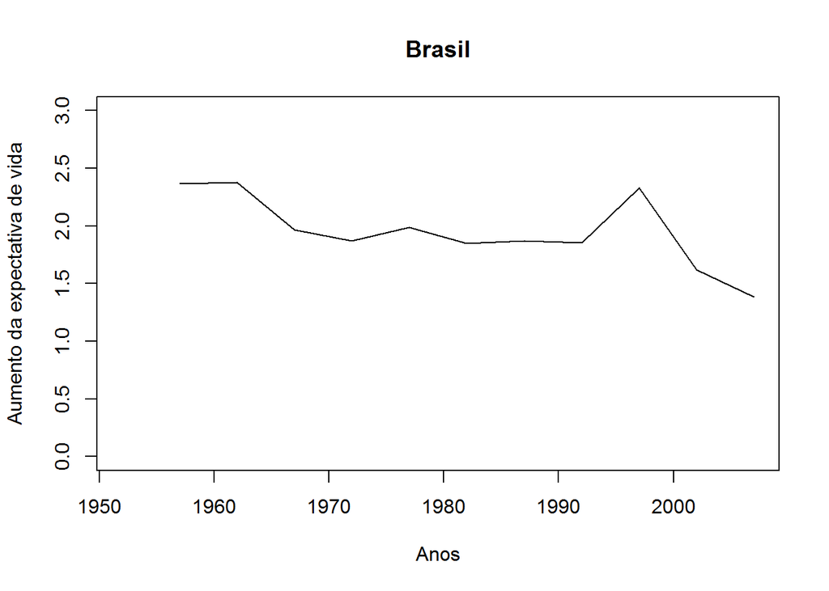

```r
am2 <- america %>%
          filter(country =="Brazil") %>%
          arrange(lifeExp)

plot(am2$year,am2$le_delta,
     ylim= c(0,3),
     type="l",
     main="Brasil",
     ylab="Aumento da expectativa de vida",
     xlab="Anos")
```

FIM DA SESSÃO

```r
save(list = ls(), file = "03_tidy2_all.Rdata")
```